# Estudis d'Informàtica, Multimedia i Telecomunicacions

# 3 Exercici 1.2

## 3.1 Mètode agregació jerarquica incremental (Hierarchical Agglomerative Clustering - HAC)

Funciona amb l’algoritme dels veïns més propers (k-nearest neighbours) de la següent forma:

- Assignem cada element al seu propi clúster, de manera que si té N elements, ara té N clústers, cadascun amb un sol element. Deixem que les distàncies (similitud) entre els clusters siguin iguals a les distàncies (similitud) entre els elements que contenen.
- Es troba el parell més proper (més similar) de clústers i es combinen en un únic clúster, de manera que ara tenim un clúster menys.
- Calculem distàncies (similitud) entre el nou clúster i cadascun dels clústers antics.
- Es repeteix els passos 2 i 3 fins que tots els elements siguin agrupats en un sol grup de mida N.

De formes de mesurar les distàncies entre grups tenim de diversos tipus. Provarem només: “average”, “complete” i “ward”.

Abans de tot, normalitzem les dades i calculem la distància euclidiana entre els elements.

```r
## creem la funció per normalitzar
ni <-function (x) {(x -min (x)) / (max (x) -min (x))}
seed.data.norm <- as.data.frame(lapply(seed_data[,1:7], ni))

# primer fem la matriu de la distància euclideana dels elements de la taula de llavors.
seed.data.euc <- dist(seed.data.norm, method = "euclidean")
```

### 3.1.1 Enllaç complet

Estratègia de la distància màxima o similitud mínima. En aquest mètode, també conegut (complete linkage), es considera que la distància o similitud entre dos clústers cal mesurar-la atenent a elements més dispars, és a dir, la distància o similitud entre clústers ve dada, respectivament, per la màxima distància (o mínima similitud) entre components dels clústers.

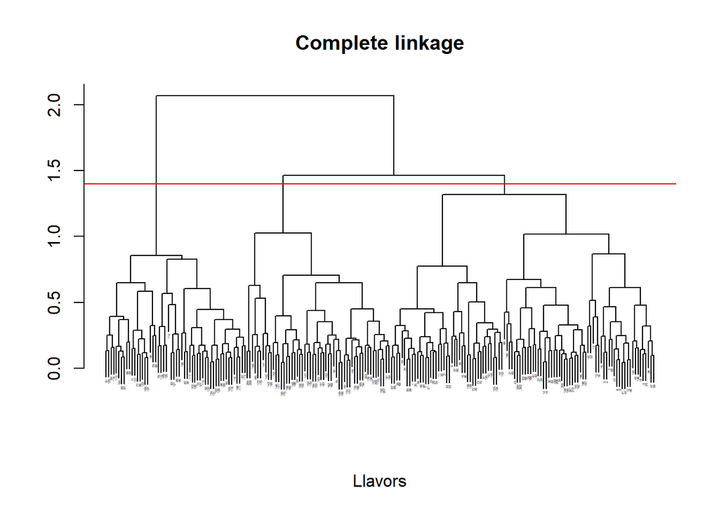

```r
# fem servir hclust per a realitzar les agrupacions
hc1 <- hclust(seed.data.euc, method = "complete")
plot(hc1,
     labels = seed.data.norm$classname,
     main = "Complete linkage",
     xlab = "Llavors",
     ylab = "",
     cex = 0.2,
     sub = "")
abline(h = 1.4, col = "red")
```

```r
hc1.cutree <- cutree(tree = hc1, k = 3)
tab <- table(hc1.cutree, seed_data$class)
tab
```

```
##
## hc1.cutree  1  2  3
##          1 69 16 16
##          2  1  0 54
##          3  0 54  0
```

```r
100*(69 + 54 + 54)/(210)
```

```
## [1] 84.28571
```

Amb aquest arbre agafariem entre 2,3 o 4 clusters.

El valor de la agrupació agant 3 clusters i comparan-lo amb el original es de 84.28571.

### 3.1.2 Enllaç promig

En aquesta estratègia la distància, o similitud, de l’clúster Ci amb el Cj s’obté com la mitjana aritmètica entre la distància, o similitud, dels elements d’aquests clústers.

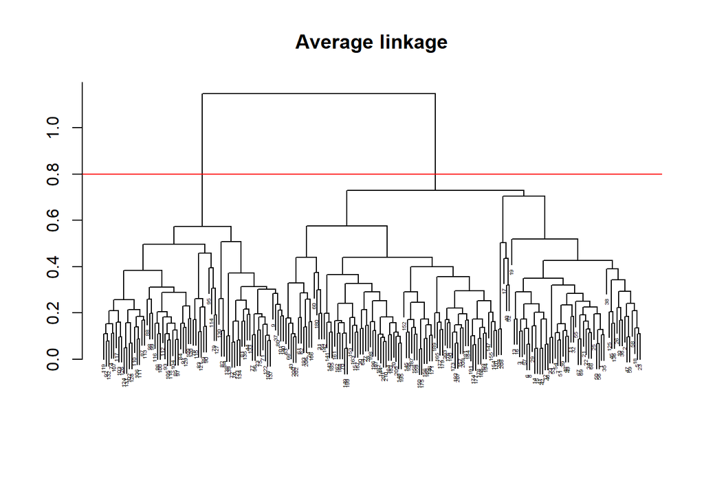

```r
seed.data.norm <- as.data.frame(lapply(seed_data[,1:7], ni))

# primer fem la matriu de la distància euclideana dels elements de la taula de llavors.
seed.data.euc <- dist(seed.data.norm, method = "euclidean")

hc2 <- hclust(seed.data.euc, method = "average")

plot(hc2,
     labels = seed.data.norm$classname,
     main = "Average linkage",
     xlab = "",
     ylab = "",
     cex = 0.3,
     sub = "")
abline(h = 0.8, col = "red")
```

```r
hc2.cutree <- cutree(tree = hc2, k = 3)
tab2 <- table(hc2.cutree, seed_data$class)
accuracy <- function(x){sum(diag(x)/(sum(rowSums(x)))) * 100}
accuracy(tab2)
```

```
## [1] 89.52381
```

Amb aquest arbre agafariem entre 2,3 o 4 clusters. Tenim una predicció dels grups d’un 89.5% d’encert, tè un porcentatge similar que amb k-means.

### 3.1.3 Mètode Ward

El mètode de Ward apunta a minimitzar la variància total dins de el grup. A cada pas, es fusionen el parell de clústers amb una distància mínima entre els clústers. En altres paraules, forma grups d’una manera que minimitza la pèrdua associada amb cada grup.

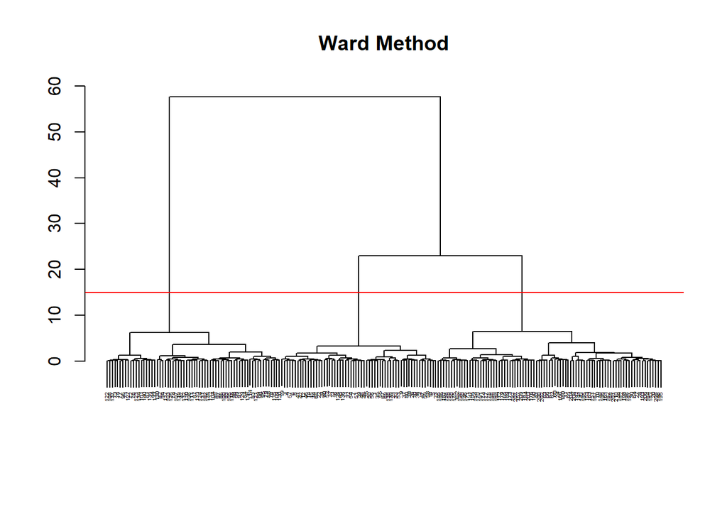

```r
hc3 <- hclust(seed.data.euc, method = "ward")

plot(hc3,
     labels = seed.data.norm$classname,
     main = "Ward Method",
     xlab = "",
     ylab = "",
     cex = 0.3,
     sub = "")
abline(h = 15, col = "red")
```

```r
hc3.cutree <- cutree(tree = hc3, k = 3)
tab3 <- table(hc3.cutree, seed_data$class)
tab3
```

```
##
## hc3.cutree  1  2  3
##          1 54  5  0
##          2 15  0 70
##          3  1 65  0
```

```r
100*(54 + 65 + 70)/(210)
```

```
## [1] 90
```

Amb el linkatge ‘ward’ tenim la millor agrupació on es pot veure clarament els 3 grups i tenim una precissió del 90%

## 3.2 Mètodes d’agregació probabilítics

Els enfocaments dels mètodes probabilístics assumeixen una varietat de models de dades i apliquen l’estimació de màxima versemblança i els criteris de Bayes per identificar el model més probable i el nombre de grups.

Anem a realitzar clusters a partir d’algoritmes probabilístics amb atributs 2 a 2

```r
seed_data.norm <- as.data.frame(lapply(seed_data[,1:7], ni))
mclust <- Mclust(seed_data.norm[,1:2])
summary(mclust)
```

```
## ----------------------------------------------------
## Gaussian finite mixture model fitted by EM algorithm
## ----------------------------------------------------
##
## Mclust EEE (ellipsoidal, equal volume, shape and orientation) model with 3
## components:
##
##  log-likelihood   n df      BIC      ICL
##        460.6463 210 11 862.4744 829.4919
##
## Clustering table:
##  1  2  3
## 62 93 55
```

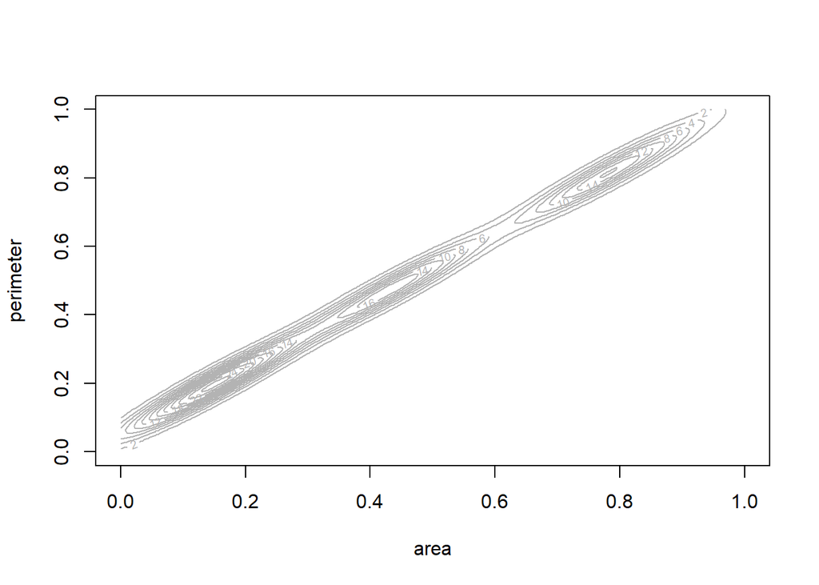

```r
plot(mclust, what = "density")
```

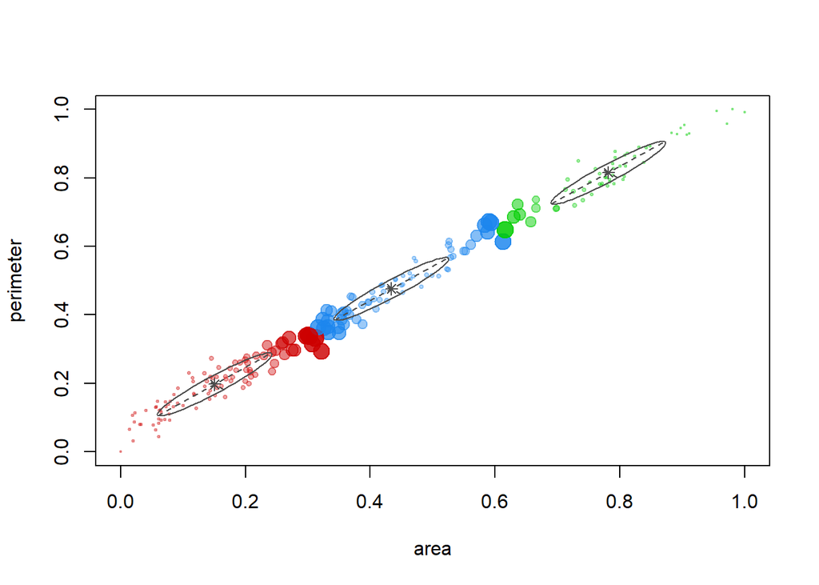

```r
plot(mclust, what = "uncertainty")
```

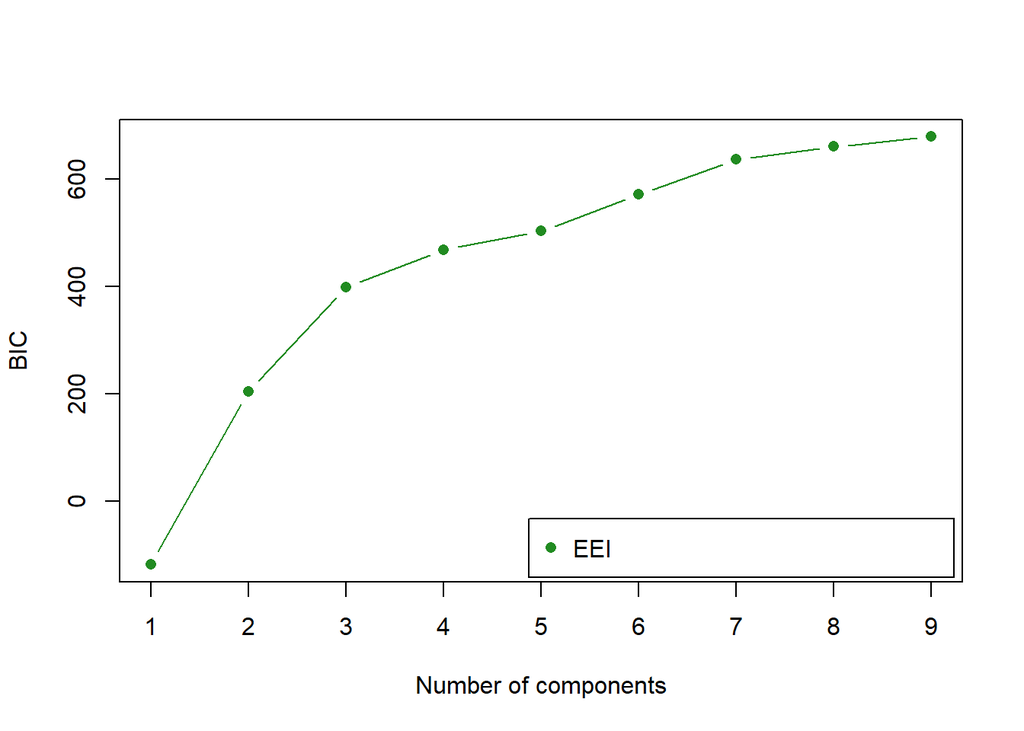

```r
legend_args <- list(x = "bottomright", ncol = 5)
plot(mclust, what = 'BIC', legendArgs = legend_args, modelName = "EEI")
```

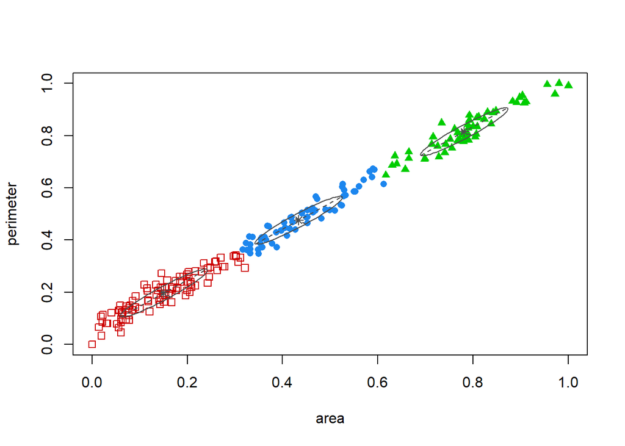

```r
plot(mclust, what = 'classification')
```

```r
mclust$G
```

```
## [1] 3
```

Es prou evident que en totes les gràfiques tenim 3 grups i el mateix objecte del clustering ens ho diu.

### 3.2.1 BIC (Bayesian Information Criterion).

Ara veiem *amb tots els atributs* fent servir el criteri BIC (Bayesian Information Criterion) per fer el clustering.

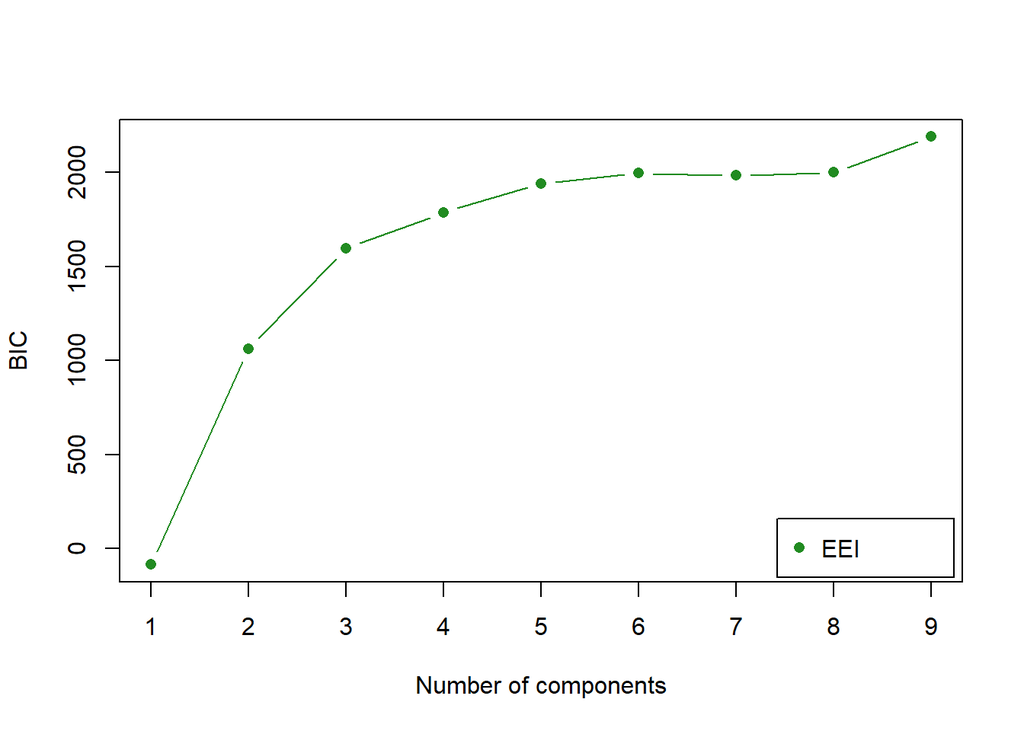

```r
clustBIC <- mclustBIC(seed_data.norm, modelName = "EEI")
plot(clustBIC)
```

## 3.3 Classificació amb K-nearest Neighbors (extra)

En la documentació s’ha explicat l’algoritme per clustering però la llibreria de RStudio knn ens permet fer *classificació supervisat*. Podem classificar elements nous mitjançant els elements k mes propers.

A diferencia de l’algoritme de K-means, aquí no partim de cap nombre predefinit de clusters (encara que sabem que son 3). Tampoc obtindrem clusters sino sabrem a quina classe pertanyen elements a partir d’un altres elements.

El que si hem de definir es el valor de K. Aquest valor indica el nombre de veins per a definir un nou grup o categoria.

Farem servir la funció de RStudio (knn). També normalitzarem els atributs per calcular les distancies. Dividirem les dades en dos conjunts, entrenament i proba, previament com hem dit normalitzats.

```r
## creem la funció per normalitzar
ni <-function (x) {(x -min (x)) / (max (x) -min (x))}

## obetnim primer una mostra del total de forma aleatoria
ran <- sample(1:nrow(seed_data), 0.5 * nrow(seed_data))


## creem la funció per normalitzar
ni <-function (x) {(x -min (x)) / (max (x) -min (x))}

## executem la normalització sobre les 7 primeres columnes i veiem com quedan
seed_data.norm <- as.data.frame(lapply(seed_data[,1:7], ni))
summary(seed_data.norm)
```

```
##       area          perimeter       compactness      lengthKernel
##  Min.   :0.0000   Min.   :0.0000   Min.   :0.0000   Min.   :0.0000
##  1st Qu.:0.1586   1st Qu.:0.2149   1st Qu.:0.4428   1st Qu.:0.2045
##  Median :0.3555   Median :0.3946   Median :0.5930   Median :0.3516
##  Mean   :0.4020   Mean   :0.4441   Mean   :0.5708   Mean   :0.4108
##  3rd Qu.:0.6341   3rd Qu.:0.6829   3rd Qu.:0.7230   3rd Qu.:0.6085
##  Max.   :1.0000   Max.   :1.0000   Max.   :1.0000   Max.   :1.0000
##   widthKernel     asymmetryCoefficient lengthKernelGroove
##  Min.   :0.0000   Min.   :0.0000       Min.   :0.0000
##  1st Qu.:0.2238   1st Qu.:0.2336       1st Qu.:0.2590
##  Median :0.4326   Median :0.3685       Median :0.3466
##  Mean   :0.4480   Mean   :0.3816       Mean   :0.4378
##  3rd Qu.:0.6641   3rd Qu.:0.5206       3rd Qu.:0.6686
##  Max.   :1.0000   Max.   :1.0000       Max.   :1.0000
```

```r
## extraiem conjunt d'entrenament amb 50% de la mostra
seed_train <- seed_data.norm [ran,]

## extraiem conjunt de prova amb el 50% de la mostra
seed_test <- seed_data.norm [-ran,]


## extraiem la 8a columna (class) del conjunt d'entrenament que utilitzarem com 'cl' a la funció knn
seed_target_category <- seed_data[ran,8]

## extraeim la 8a columna (class) del conjunt de test que farem servir per a mesurar la qualitat del model obtingut
seed_test_category <- seed_data[-ran,8]

## executem la funció knn
pr <- knn(seed_train,seed_test,cl=seed_target_category,k=5)

## creem la matriu per avaluar la prova
tab <- table(pr,seed_test_category)

## funció per avaluar la qualitat del model
accuracy <- function(x){sum(diag(x)/(sum(rowSums(x)))) * 100}
accuracy(tab)
```

```
## [1] 90.47619
```

Tenim uns resultats prou bons. A partir de la mostra d’entrenament ha sabut classificar de forma correcta un % molt elevat dels elements de test.

# 4 Exercici 2.1

## 4.1 Estudi previ i preparació de les dades

```r
# carreguem les dades i strings els factoritzem
lastfm.data<-read.csv('lastfm.csv',stringsAsFactors = FALSE)

# veiem el nombre de registres que tenim
str(dim(lastfm.data)[1])
```

```
##  int 289955
```

```r
# veiem l'estructura de les dades
str(lastfm.data)
```

```
## 'data.frame':    289955 obs. of  4 variables:
##  $ user   : int  1 1 1 1 1 1 1 1 1 1 ...
##  $ artist : chr  "red hot chili peppers" "the black dahlia murder" "goldfrapp" "dropkick murphys" ...
##  $ sex    : chr  "f" "f" "f" "f" ...
##  $ country: chr  "Germany" "Germany" "Germany" "Germany" ...
```

```r
summary(lastfm.data)
```

```
##       user          artist              sex              country
##  Min.   :    1   Length:289955      Length:289955      Length:289955
##  1st Qu.: 4935   Class :character   Class :character   Class :character
##  Median : 9838   Mode  :character   Mode  :character   Mode  :character
##  Mean   : 9852
##  3rd Qu.:14769
##  Max.   :19718
```

El conjunt de les dades es composa de 289955 registres amb 4 columnes:

- user: es un enter que identifica al usuari de l’escolta
- artist: cadena de chars que identifica el grup escoltat
- sex: char que identifica el sexe amb valors f/m
- country: cadena de chars que identifica el país de procedencia del usuari

### 4.1.1 Tractament de valors buits

```r
colSums(is.na(lastfm.data))
```

```
##    user  artist     sex country
##       0       0       0       0
```

No tenim valors buits, per tant no hem de tractar aquests valors.

### 4.1.2 Discretitzem les dades i les carreguem com a transaccions

```r
# discretitzem les dades
for (i in 1:4) {
  lastfm.data[,i] <- as.factor(lastfm.data[,i])
}

summary(lastfm.data)
```

```
##       user                          artist       sex
##  17681  :    76   radiohead            :  2704   f: 78132
##  15057  :    63   the beatles          :  2668   m:211823
##  1208   :    55   coldplay             :  2378
##  19558  :    55   red hot chili peppers:  1786
##  13424  :    54   muse                 :  1711
##  3288   :    52   metallica            :  1670
##  (Other):289600   (Other)              :277038
##            country
##  United States : 59558
##  United Kingdom: 27638
##  Germany       : 24251
##  Poland        : 17111
##  Sweden        : 12379
##  Brazil        : 11922
##  (Other)       :137096
```

### 4.1.3 Estudi de la repetició del camp artist

```r
# transformem el data en una llista dels artistes agrupats per els usuaris, es a dir, tenim els artistes que escolta cada usuari

# contem el número d'usuaris diferents i ens surten 15000. Tindrem 15000 transaccions
users <- lastfm.data[,"user"]
n_distinct(users)
```

```
## [1] 15000
```

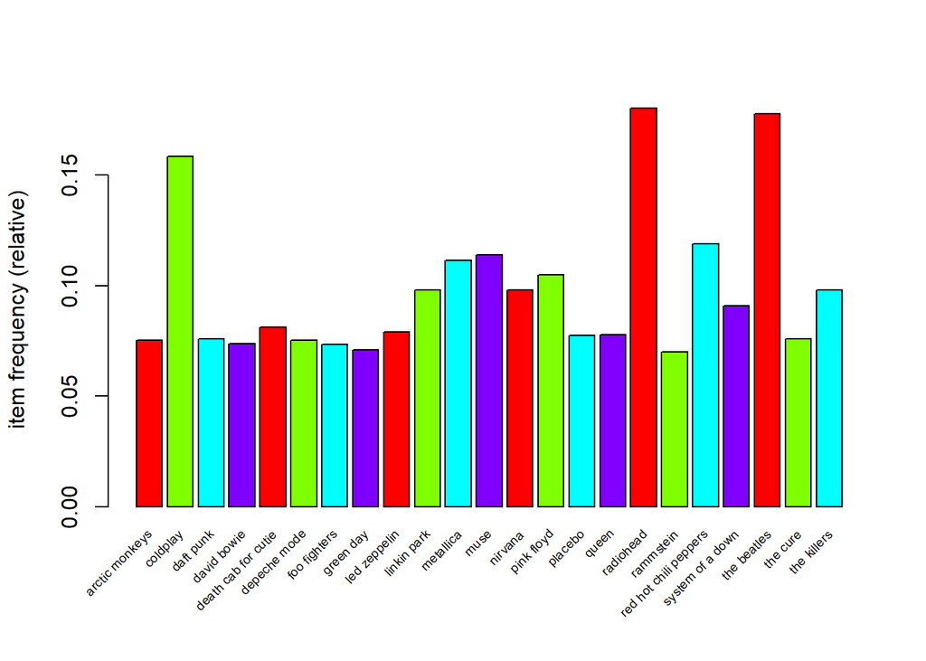

```r
artist <- split(x=lastfm.data[,"artist"],f=lastfm.data$user)

# trasformem el data com a transactions. Cada transacció es un usuari i els artistes que ha escoltat
artist.transactions <- as(artist,"transactions")
itemFrequencyPlot(artist.transactions, support = .07, cex.names = .6, col = rainbow(4))
```

Mostrem els artistes que mes es repeteixen. En concret estem mostrant aquells que tenen un suport o freqüencia >= 0.07. Si tenim 15000 transaccions, estem mostrant x >= 15.000 * 0.7, es a dir aquells que apareixen com a mínim 1050 vegades.

Els artistes que més es repeteixen són Coldplay, Radiohead i The Beatles.

Com a curiositat anem a fer la mateixa comprobació però separant per sexe

```r
male <- subset(lastfm.data, lastfm.data$sex == "m")
artist <- split(x=male[,"artist"],f=male$user)
male.transactions <- as(artist,"transactions")
```

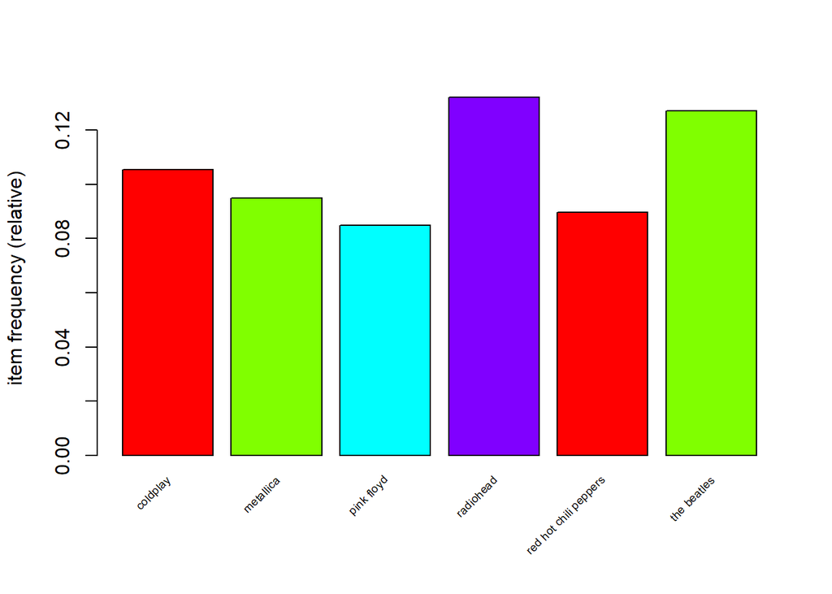

```r
itemFrequencyPlot(male.transactions, support = .08, cex.names = .6, col = rainbow(4))
```

```r
female <- subset(lastfm.data, lastfm.data$sex == "f")
artist2 <- split(x=female[,"artist"],f=female$user)
female.transactions <- as(artist2,"transactions")
```

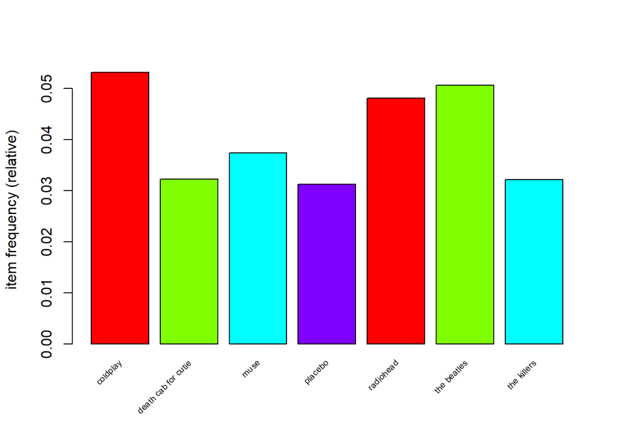

```r
itemFrequencyPlot(female.transactions, support = .03, cex.names = .6, col = rainbow(4))
```

Els 3 primers continuan sent els mateixos.

## 4.2 Aplicació d’algoritme apriori

Si llancem l’algoritme “apriori”, generarem directament un set de regles amb diferent suport, confiança i lift.

- El *support* indica quantes vegades s’han trovat les regles {lsh => rhs} en el dataset, com més alt millor. Es la “popularitat” d’un conjunt d’elements del dataset. On {lsh => rhs} indica que si s’escolta lsh, s’escolta rhs.
- La *confidence* ens parla de la probabilitat que s’escolti {rhs} si s’escolta {lhs} (lhs => rhs / lhs).
- El *lift* és un paràmetre que ens indica quan d’aletorietat hi ha a les regles. Un lift de 1 o menys ens indica que la regla és completament fruit de l’atzar. El lift ens diu eb una regla, com es produeix la regla en funció dels elements de la regla (support(lhs => rhs) / support(lhs) * support(rhs)).

```r
artist_rules <- apriori(artist.transactions, parameter = list(support = 0.01, confidence = 0.4))
```

```
## Apriori
##
## Parameter specification:
##  confidence minval smax arem  aval originalSupport maxtime support minlen
##         0.4    0.1    1 none FALSE            TRUE       5    0.01      1
##  maxlen target   ext
##      10  rules FALSE
##
## Algorithmic control:
##  filter tree heap memopt load sort verbose
##     0.1 TRUE TRUE  FALSE TRUE    2    TRUE
##
## Absolute minimum support count: 150
##
## set item appearances ...[0 item(s)] done [0.00s].
## set transactions ...[1004 item(s), 15000 transaction(s)] done [0.10s].
## sorting and recoding items ... [655 item(s)] done [0.01s].
## creating transaction tree ... done [0.01s].
## checking subsets of size 1 2 3 4 done [0.03s].
## writing ... [211 rule(s)] done [0.00s].
## creating S4 object  ... done [0.00s].
```

```r
inspect(head(sort(artist_rules, by = "confidence"), 10))
```

```
##      lhs                                    rhs           support    confidence
## [1]  {oasis,the killers}                 => {coldplay}    0.01113333 0.6626984
## [2]  {sigur rÃ³s,the beatles}            => {radiohead}   0.01046667 0.6434426
## [3]  {keane}                             => {coldplay}    0.02226667 0.6374046
## [4]  {radiohead,snow patrol}             => {coldplay}    0.01006667 0.6344538
## [5]  {coldplay,the smashing pumpkins}    => {radiohead}   0.01093333 0.6283525
## [6]  {the beatles,the smashing pumpkins} => {radiohead}   0.01146667 0.6209386
## [7]  {bob dylan,pink floyd}              => {the beatles} 0.01033333 0.6150794
## [8]  {led zeppelin,the doors}            => {pink floyd}  0.01066667 0.5970149
## [9]  {snow patrol,the killers}           => {coldplay}    0.01040000 0.5954198
## [10] {bob dylan,the rolling stones}      => {the beatles} 0.01146667 0.5910653
##      lift     count
## [1]  4.180183 167
## [2]  3.569393 157
## [3]  4.020634 334
## [4]  4.002021 151
## [5]  3.485683 164
## [6]  3.444556 172
## [7]  3.458092 155
## [8]  5.689469 160
## [9]  3.755802 156
## [10] 3.323081 172
```

Amb aquesta ordenació per *confidence*, tenim una probabilitat alta que si escoltan “the killers” + “oasis”, escoltin “coldplay”. Es un exemple, el mateix passa amb la resta de les 9 regles mostrades. Si algú escoltés “keane” li recomanaria en la seva llista de reproducció “coldplay”. En tots els casos el lift es molt superior a 1, per tant no hi ha aletorietat en els resultats.

```r
inspect(head(sort(artist_rules, by = "support"), 10))
```

```
##      lhs                        rhs           support    confidence lift
## [1]  {the killers}           => {coldplay}    0.04106667 0.4181942  2.637894
## [2]  {bob dylan}             => {the beatles} 0.03446667 0.4971154  2.794877
## [3]  {sigur rÃ³s}            => {radiohead}   0.03420000 0.4927954  2.733702
## [4]  {led zeppelin}          => {the beatles} 0.03346667 0.4225589  2.375706
## [5]  {led zeppelin}          => {pink floyd}  0.03200000 0.4040404  3.850449
## [6]  {david bowie}           => {the beatles} 0.03173333 0.4307692  2.421866
## [7]  {the rolling stones}    => {the beatles} 0.03046667 0.4841102  2.721759
## [8]  {the smashing pumpkins} => {radiohead}   0.02993333 0.4885745  2.710288
## [9]  {iron maiden}           => {metallica}   0.02960000 0.4994376  4.485966
## [10] {beck}                  => {radiohead}   0.02926667 0.5092807  2.825152
##      count
## [1]  616
## [2]  517
## [3]  513
## [4]  502
## [5]  480
## [6]  476
## [7]  457
## [8]  449
## [9]  444
## [10] 439
```

Si ordenem per support, veiem les regles que més cops s’han produït a tot el conjunt. La regla escoltar “the killers” => “coldplay” s’ha produït mes de 600 cops. Una altre repetició de regla alta és “bob dylan” => “the beatles”. Aquestes regles tenen a més una probabilitat condicionada (confidence) relativament alta > 40%

Podem generar altres regles que impliquin un mínim de dos elements del lhs:

```r
artist_rules2 <- apriori(artist.transactions, parameter = list(support = 0.01, confidence = 0.4, minlen=3))
```

```
## Apriori
##
## Parameter specification:
##  confidence minval smax arem  aval originalSupport maxtime support minlen
##         0.4    0.1    1 none FALSE            TRUE       5    0.01      3
##  maxlen target   ext
##      10  rules FALSE
##
## Algorithmic control:
##  filter tree heap memopt load sort verbose
##     0.1 TRUE TRUE  FALSE TRUE    2    TRUE
##
## Absolute minimum support count: 150
##
## set item appearances ...[0 item(s)] done [0.00s].
## set transactions ...[1004 item(s), 15000 transaction(s)] done [0.13s].
## sorting and recoding items ... [655 item(s)] done [0.01s].
## creating transaction tree ... done [0.01s].
## checking subsets of size 1 2 3 4 done [0.03s].
## writing ... [98 rule(s)] done [0.00s].
## creating S4 object  ... done [0.00s].
```

```r
inspect(head(sort(artist_rules2, by = "confidence"), 10))
```

```
##      lhs                                    rhs           support    confidence
## [1]  {oasis,the killers}                 => {coldplay}    0.01113333 0.6626984
## [2]  {sigur rÃ³s,the beatles}            => {radiohead}   0.01046667 0.6434426
## [3]  {radiohead,snow patrol}             => {coldplay}    0.01006667 0.6344538
## [4]  {coldplay,the smashing pumpkins}    => {radiohead}   0.01093333 0.6283525
## [5]  {the beatles,the smashing pumpkins} => {radiohead}   0.01146667 0.6209386
## [6]  {bob dylan,pink floyd}              => {the beatles} 0.01033333 0.6150794
## [7]  {led zeppelin,the doors}            => {pink floyd}  0.01066667 0.5970149
## [8]  {snow patrol,the killers}           => {coldplay}    0.01040000 0.5954198
## [9]  {bob dylan,the rolling stones}      => {the beatles} 0.01146667 0.5910653
## [10] {beck,the beatles}                  => {radiohead}   0.01300000 0.5909091
##      lift     count
## [1]  4.180183 167
## [2]  3.569393 157
## [3]  4.002021 151
## [4]  3.485683 164
## [5]  3.444556 172
## [6]  3.458092 155
## [7]  5.689469 160
## [8]  3.755802 156
## [9]  3.323081 172
## [10] 3.277972 195
```

```r
inspect(head(sort(artist_rules2, by = "support"), 10))
```

```
##      lhs                                  rhs           support    confidence
## [1]  {coldplay,the beatles}            => {radiohead}   0.01953333 0.4406015
## [2]  {coldplay,muse}                   => {radiohead}   0.01833333 0.4725086
## [3]  {muse,radiohead}                  => {coldplay}    0.01833333 0.4263566
## [4]  {pink floyd,the beatles}          => {radiohead}   0.01606667 0.4050420
## [5]  {pink floyd,radiohead}            => {the beatles} 0.01606667 0.4688716
## [6]  {led zeppelin,pink floyd}         => {the beatles} 0.01560000 0.4875000
## [7]  {led zeppelin,the beatles}        => {pink floyd}  0.01560000 0.4661355
## [8]  {muse,the killers}                => {coldplay}    0.01513333 0.5089686
## [9]  {radiohead,the killers}           => {coldplay}    0.01506667 0.5243619
## [10] {radiohead,red hot chili peppers} => {coldplay}    0.01480000 0.4683544
##      lift     count
## [1]  2.444165 293
## [2]  2.621165 275
## [3]  2.689381 275
## [4]  2.246905 241
## [5]  2.636085 241
## [6]  2.740817 234
## [7]  4.442206 234
## [8]  3.210483 227
## [9]  3.307582 226
## [10] 2.954296 222
```

```r
inspect(head(sort(artist_rules2, by = "lift"), 10))
```

```
##      lhs                           rhs                   support    confidence
## [1]  {pink floyd,the doors}     => {led zeppelin}        0.01066667 0.5387205
## [2]  {led zeppelin,the doors}   => {pink floyd}          0.01066667 0.5970149
## [3]  {radiohead,the shins}      => {death cab for cutie} 0.01006667 0.4441176
## [4]  {coldplay,franz ferdinand} => {the killers}         0.01060000 0.4922601
## [5]  {bloc party,coldplay}      => {the killers}         0.01106667 0.4811594
## [6]  {arctic monkeys,muse}      => {the killers}         0.01106667 0.4636872
## [7]  {arctic monkeys,coldplay}  => {the killers}         0.01233333 0.4545455
## [8]  {placebo,radiohead}        => {muse}                0.01366667 0.5137845
## [9]  {led zeppelin,the beatles} => {pink floyd}          0.01560000 0.4661355
## [10] {coldplay,oasis}           => {the killers}         0.01113333 0.4271100
##      lift     count
## [1]  6.802027 160
## [2]  5.689469 160
## [3]  5.460463 151
## [4]  5.012832 159
## [5]  4.899790 166
## [6]  4.721865 166
## [7]  4.628772 185
## [8]  4.504247 205
## [9]  4.442206 234
## [10] 4.349389 167
```

La regla “coldplay + the beatles => radiohead” és la que més cops es produeix, més freqüencia (support) i la probabilitat més alta es “oasis + the killers => coldplay”.

Ordenat per el lift tenim “pink floyd + the doors => led zeppelin”. Aquesta regla es la que té una aletorietat més baixa. Els elements lhs i rhs están prou estesos al dataset. Si tinguessim una aletorietat per sota d’1 diria que els elements de la regla lhs i rhs es produeixen força cops en el dataset, molt més que la repetició de la regla, i que la regla s’ha produït de forma fortuita per aquest motiu